# Homework: Simulation

Example: Hearts

## Is it in the cards?

In this task, you will create a simulation of a card game played with a standard deck of 52 cards. You might consider games such as [blackjack](https://bicyclecards.com/how-to-play/blackjack/#filter), [war](https://bicyclecards.com/how-to-play/war/#filter), or [go fish](https://bicyclecards.com/how-to-play/go-fish/#filter). You may choose any game that can be assessed probabilistically – you may want to avoid games which require a large amount of strategy, skill, and bluffing, such as poker.

This homework file is set up to demonstrate how this would be done with the game of [hearts](https://bicyclecards.com/how-to-play/hearts/#filter).

You don’t need to necessarily simulate the full game mechanism, but you do need to implement enough of the game mechanism that you can identify an interesting probability question in your game and answer the question using a simulation.

### Set up your objects

First, you must set up a data frame describing all possible values of your playing items. For instance, if you are using a standard deck of 52 playing cards, you’ll need a data frame which has columns for suit and value, and you may want to make value a factor variable (your call on that one). If your game requires that players hold cards in their hand, you may also want to have a column indicating location (deck, discard, player_x).

```
Pseudocode: Set up objects

Create a tibble with 4 suits and 13 values labeled Ace, 2:10, J, Q, K
Add point values
Add card ID numbers
(Eventually) add location column - defer to a later step
Remove any cards from the deck not necessary for game play
```

```r
library(tidyverse)
create_deck <- function() {
  # Set up cards
  suits <- c("hearts", "diamonds", "spades", "clubs")

  values <- factor(1:13, labels = c(2:10, "Jack", "Queen", "King", "Ace"))
  deck <- crossing(suit = suits, value = values)

  # Set up points
  # This will change depending on which game you want to simulate
  # I have demonstrated this using hearts
  deck %>%
    mutate(points = (suit == "hearts") +
             13*(suit == "spades" & value == "Queen")) %>%
    # add a card ID
    mutate(id = 1:n())
}

create_deck()
```

```
## # A tibble: 52 × 4
##    suit  value points    id
##    <chr> <fct>  <dbl> <int>
##  1 clubs 2          0     1
##  2 clubs 3          0     2
##  3 clubs 4          0     3
##  4 clubs 5          0     4
##  5 clubs 6          0     5
##  6 clubs 7          0     6
##  7 clubs 8          0     7
##  8 clubs 9          0     8
##  9 clubs 10         0     9
## 10 clubs Jack       0    10
## # … with 42 more rows
```

I’ve created a standard deck of cards, and assigned each card the point value it has when scoring a game of hearts.

In the Bicycle rules, there are specific cards which are removed if there are 3 or 5 players (to make sure there are an even number of cards for each player). I’m deviating slightly from those rules so that the 2 of clubs is always available (this makes my life easier), but the fundamentals are the same.

```r
deck_fix <- function(deck = create_deck(), n_players = 4) {

  # Remove cards from deck to make the game playable by 3 or 5 players
  if (n_players == 4) {
    # do nothing special
  } else if (n_players == 3) {
    deck <- deck %>%
      filter(!(suit == "diamonds" & value == "2"))
  } else if (n_players == 5) {
    deck <- deck %>%
      filter(!(suit %in% c("diamonds", "spades") & value == "2"))
  } else {
    stop("Hearts is playable by between 3 and 5 players")
  }

  deck
}

create_deck() %>%
  deck_fix(n_players = 3) %>%
  arrange(value, suit)
```

```
## # A tibble: 51 × 4
##    suit     value points    id
##    <chr>    <fct>  <dbl> <int>
##  1 clubs    2          0     1
##  2 hearts   2          1    27
##  3 spades   2          0    40
##  4 clubs    3          0     2
##  5 diamonds 3          0    15
##  6 hearts   3          1    28
##  7 spades   3          0    41
##  8 clubs    4          0     3
##  9 diamonds 4          0    16
## 10 hearts   4          1    29
## # … with 41 more rows
```

### Write one or more functions to simulate the basic game mechanisms

For instance, if you are simulating a game where all cards are initially held by players, you need to have a function that randomly assigns 13 cards to each player. You may also want a function that controls the game play and functions for each separate step in game play (some of these functions may need to be called using a loop).

```
Pseudocode:

Full game:
1. Deal Cards
2. Play the first trick
    1. The player with the 2 of clubs starts
    2. Each player must select a card (see function below)
3. Play 12 more tricks (mostly, this is a repeat of step 2, but the first player selects a random card instead of the 2 of clubs)
    1. Each player must select a card
    2. The trick must be evaluated to determine which player keeps the cards
4. Determine the game score by counting up the value of the hearts and queen of spades cards in each hand. Lowest score wins.

Card selection:
1. If the player has any cards in suit, they must select one of those cards
2. If a card in suit isn't available, the player may select an out of suit card. Hearts cannot be played until the suit is "broken" or there is no other option.
    1. Determine set of cards available to select from (see Available card function)
    2. Randomly select a card from available options

Available cards:
    1. Check if hearts have been broken
        - if not, check if other cards are available
            - if other cards are available, remove all hearts from the "options"
        - return available cards data frame
```

#### Deal cards to players

```r
deal_cards <- function(deck, players = 1:4) {
  deck %>%
    # Fix the deck
    deck_fix(n_players = length(players)) %>%
    # shuffle the rows
    slice_sample(n = nrow(deck)) %>%
    # Assign cards to players one-by-one
    mutate(player = rep(players, length.out = n())) %>%
    # Sort deck by player, suit, and value
    arrange(player, suit, value)
}

create_deck() %>%
  deal_cards(players = c("Amy", "Joe", "Sarah", "Bill")) %>%
  group_by(player) %>%
  count()
```

```
## # A tibble: 4 × 2
## # Groups:   player [4]
##   player     n
##   <chr>  <int>
## 1 Amy       13
## 2 Bill      13
## 3 Joe       13
## 4 Sarah     13
```

#### Picking Cards

Next, we need to handle how a player would select a card. We’re going to ignore any sort of logic that would depend on cards played by previous players in the same trick (or previous tricks). Remember, I’m simulating my siblings and I playing this game when I was at most 11 (and I was the oldest), so it’s a 100% safe assumption that our logical skills were … suboptimal.

In Hearts, like in many other trick-based games, you have certain rules that must be followed, like matching suits.

```r
# Check whether there's a card in the selected suit
pick_card_in_suit <- function(cards, sel_suit = NA) {
  # if sel_suit is NA, this will return nothing
  filter(cards, suit == sel_suit) %>%
    slice_sample(n = 1)
}
```

In addition, hearts requires that if no point cards have been played yet, you must select a card which is not a point card (so something other than a heart or the queen of spades) if you have the option to do so.

We handle this using the `hearts_available` parameter, which describes whether point cards have been played. If hearts aren’t available, and there are other suits in the set of cards, we will pick a non-heart card.

```r
# Check whether there's a card in another suit
pick_card_out_suit <- function(cards, hearts_avail = F) {
  if (is.na(hearts_avail)) stop("hearts_avail cannot be NA")
  card_options <- cards

  nonhearts <- any(cards$suit != "hearts")

  # If hearts aren't available and there are other suits,
  # filter out the hearts
  # Note that this still allows the Queen of Spades to
  # be played at any time (which then makes hearts available)
  if (nonhearts & !hearts_avail) {
    card_options <- cards %>% filter(suit != "hearts")
  }

  # print(card_options)
  slice_sample(card_options, n = 1)
}
```

(This logic caused 90% of the trouble I had with this game simulation)

Now that we have that, we can write a function that will take a set of cards, and pick a card for a given player in the selected suit (if provided).

```r
pick_card <- function(deck,
                      this_player = NA,
                      sel_suit = NA,
                      hearts_avail = F) {
  if (!is.na(this_player)) {
    options <- filter(deck, player %in% this_player)
  } else {
    options <- deck
  }

  play <- bind_rows(
    # First, try to pick something in suit
    pick_card_in_suit(options, sel_suit = sel_suit),
    # Then if that fails pick something out of suit
    pick_card_out_suit(options, hearts_avail = hearts_avail)
  )

  # Take the first row - in-suit if it's available, out-of-suit otherwise
  play[1,]
}
```

#### Playing the first trick

The first trick is a bit different, logic wise. The person with the 2 of clubs leads (in other tricks, it’s the person who took the previous trick).

To make this function a bit easier to use, I’ve created a couple of helper functions that can be re-used in any trick:

```r
# Evaluate a played trick, adding columns for trick_order, in_suit, player_win, and trick number
eval_trick <- function(cards, spec_suit, trick_num = NA) {
  cards %>%
    mutate(trick_order = 1:n()) %>%
    mutate(in_suit = suit == spec_suit) %>%
    arrange(desc(in_suit), desc(value)) %>%
    mutate(player_win = .$player[1]) %>%
    arrange(trick_order) %>%
    mutate(trick = trick_num)
}

# Remove cards from deck that have been played and bind on as a played trick
fix_deck <- function(dealt, trick) {
  dealt %>%
    anti_join(trick, by = c("suit", "value", "player", "id")) %>%
    bind_rows(trick)
}
```

This leads to the code for the first trick:

```r
first_trick <- function(dealt) {
  # Which player has 2 of clubs?
  first_card <- dealt %>%
    filter(suit == "clubs" & value == "2")

  remaining_players <- unique(dealt$player) %>%
    setdiff(first_card$player)

  play <- first_card
  for (i in remaining_players) {
    play <- dealt %>%
      filter(player == i) %>%
      pick_card(sel_suit = "clubs") %>%
      bind_rows(play)
  }
  play <- play %>%
    eval_trick(spec_suit = "clubs",
               trick_num = 1)

  if (!all(dealt$player %in% play$player)) {
    stop("Not all players picked cards?")
  }

  fix_deck(dealt, play)
}
```

#### General trick

The same basic logic applies in any trick - the first card is picked, and then all other players throw in a card. We do need a hearts_playable function that will evaluate our deck to see if hearts is an option; once we have that, we can write a general trick-playing function.

Notice that we’re calling the first_trick function within this function - this makes it much easier to remember the syntax.

```r
hearts_playable <- function(df) {
  sum(df$points, na.rm = T) > 0
}

play_trick <- function(dealt) {
  if (!"trick" %in% names(dealt)) {
    return(first_trick(dealt))
  }

  # get empty df
  play <- filter(dealt, id < 0)

  # get trick number
  trick_num <- (1 + dealt$trick) %>% max(na.rm = T)

  # get player to lead
  avail <- filter(dealt, is.na(trick))
  last_player <- filter(dealt, trick == max(trick, na.rm = T)) %>%
    pluck("player_win") %>%
    unique()

  # get already played cards and see if hearts can be played
  already_played <- anti_join(dealt, avail, by = c("suit", "value"))
  can_play_hearts <- bind_rows(already_played, play) %>%
    hearts_playable()

  # pick first card
  play <- pick_card(avail,
                    this_player = last_player,
                    sel_suit = NA,
                    hearts_avail = can_play_hearts)

  # pick remaining cards
  remaining_players <- unique(dealt$player) %>%
    setdiff(last_player)
  for (i in remaining_players) {
    can_play_hearts <- bind_rows(already_played, play) %>%
      hearts_playable()
    play <- bind_rows(
      play,
      pick_card(avail, this_player = i,
                sel_suit = play$suit[1],
                hearts_avail = can_play_hearts)
    )
  }

  # evaluate the trick
  play <- play %>%
    eval_trick(spec_suit = play$suit[1], trick_num)

  # remove trick from deck and add it back in as a played trick
  fix_deck(dealt, play)
}

create_deck() %>%
deal_cards(players = c("Amy", "Joe", "Sarah", "Bill")) %>%
play_trick() %>%
play_trick() %>%
filter(!is.na(trick)) # first 2 tricks in a game
```

```
## # A tibble: 8 × 9
##   suit  value points    id player trick_order in_suit player_win trick
##   <chr> <fct>  <dbl> <int> <chr>        <int> <lgl>   <chr>      <dbl>
## 1 clubs 9          0     8 Joe              1 TRUE    Bill           1
## 2 clubs Ace        0    13 Bill             2 TRUE    Bill           1
## 3 clubs Jack       0    10 Amy              3 TRUE    Bill           1
## 4 clubs 2          0     1 Sarah            4 TRUE    Bill           1
## 5 clubs 5          0     4 Bill             1 TRUE    Amy            2
## 6 clubs Queen      0    11 Amy              2 TRUE    Amy            2
## 7 clubs 10         0     9 Joe              3 TRUE    Amy            2
## 8 clubs 3          0     2 Sarah            4 TRUE    Amy            2
```

#### Play a full game

Now, we can play a full game of hearts by repeatedly calling the play_trick function. All of the cards stay in the same data frame, and we keep track of who won each trick and who played each card - this allows us to calculate the score for each player at the end.

```r
hearts <- function(players) {
  deck <- create_deck() %>%
    deal_cards(players)

  number_of_rounds <- nrow(deck)/length(players)

  for (i in 1:number_of_rounds) {
    # print(i)
    deck <- play_trick(deck)
    # print(filter(deck, trick == i))
  }

  return(deck)
}

hearts(c("Amy", "Beth", "Cara", "Dawn"))
```

```
## # A tibble: 52 × 9
##    suit   value points    id player trick_order in_suit player_win trick
##    <chr>  <fct>  <dbl> <int> <chr>        <int> <lgl>   <chr>      <dbl>
##  1 clubs  4          0     3 Dawn             1 TRUE    Amy            1
##  2 clubs  5          0     4 Beth             2 TRUE    Amy            1
##  3 clubs  Jack       0    10 Amy              3 TRUE    Amy            1
##  4 clubs  2          0     1 Cara             4 TRUE    Amy            1
##  5 clubs  7          0     6 Amy              1 TRUE    Cara           2
##  6 clubs  10         0     9 Beth             2 TRUE    Cara           2
##  7 clubs  Ace        0    13 Cara             3 TRUE    Cara           2
##  8 clubs  6          0     5 Dawn             4 TRUE    Cara           2
##  9 spades King       0    51 Cara             1 TRUE    Cara           3
## 10 spades Queen     13    50 Amy              2 TRUE    Cara           3
## # … with 42 more rows
```

#### Calculate game_score

It’s pretty easy given our setup to calculate each player’s score:

```r
calc_score <- function(data) {
  game <- data %>%
    group_by(player) %>%
    summarize(score = sum(points), .groups = "drop")

  # Handle the "shoot the moon" scenario
  # where one player has all the points
  if (any(game$score == 26)) {
    game <- game %>%
      mutate(score = 26 - score)
  }
  game
}


hearts(c("Amy", "Beth", "Cara", "Dawn")) %>%
  calc_score()
```

```
## # A tibble: 4 × 2
##   player score
##   <chr>  <dbl>
## 1 Amy       16
## 2 Beth       5
## 3 Cara       1
## 4 Dawn       4
```

### Identify a probability question you can answer with your simulation

For instance, if you are simulating blackjack, you may want to know what the [expected return on a specific strategy is](https://towardsdatascience.com/python-blackjack-simulator-61b591ffb971) (hint: if you’re beating the dealer, your simulation is probably wrong).

Fundamentally, my question is what the probability is that a player using relatively little strategy accidentally “shoots the moon”.

In a shoot the moon scenario, the total game points will be (n-1) times normal, where $n$ is the number of players. This function returns a logical indicator of whether or not the total number of points generated is more than 26 (indicating that someone shot the moon)

```r
shoot_the_moon <- function(data) {
  sum(data$score) > 26
}
```

### Design a simulation to answer the question you identified

Run your simulation with an increasing number of iterations and create some sort of plot showing your results.

Describe any issues you encountered in your simulation, and how you addressed them (or where the whole thing went off the rails, if you couldn’t address everything in time).

```r
# I'm saving the results of this so that I only
# have to run it once...

# This uses parallel processing to take advantage of the
# fact that I wrote this on a server with 16 cores and
# a lot of memory.
# May as well use the power if you have the option!
library(parallel)
set.seed(34029)
#... then parallel replicate...
games <- mclapply(1:10000, FUN = function(i) { hearts(c("Susan", "Caroline", "Mom", "Dad")) }, mc.preschedule = F, mc.set.seed = T, mc.cores = 16, mc.cleanup = T)

save(games, file = "games.Rdata")
```

```r
load("games.Rdata")
res <- tibble(
  full_game = games,
  score = purrr::map(full_game, calc_score),
  stm = purrr::map_lgl(score, shoot_the_moon)
)
```

From this assessment, one player shoots the moon in approximately 0.00% of games played using the naive strategy. My parents were probably pretty reasonably assuming that they could explain that part of the strategy later, once we’d grasped the fundamentals of the game.

I wish I had time to add in some strategy component, but I think at this point that would be excessive.

Note that we can compute other interesting quantities from our simulated set of games, such as the total proportion of points on the board once there $x$ tricks played.

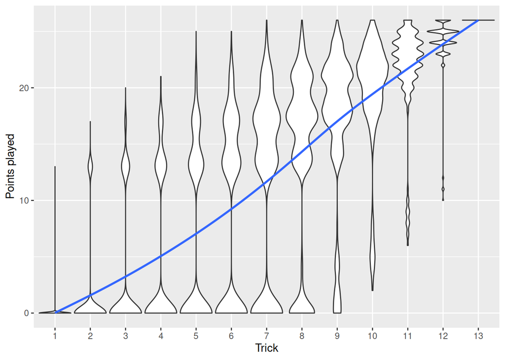

```r
points_trick_cumulative <- function(game) {
  game %>%
    group_by(trick) %>%
    summarize(points = sum(points))
}

library(parallel)
points_cumulative <- res %>%
  select(full_game) %>%
  mutate(tmp = mclapply(full_game, points_trick_cumulative, mc.cores = 16))

points_cumulative %>%
  mutate(id = 1:n()) %>%
  unnest(tmp) %>%
  group_by(id) %>%
  mutate(points_played = cumsum(points),
         point_pct = points_played/sum(points)) %>%
  ggplot(aes(x = factor(trick), y = points_played)) +
  geom_violin(scale = "width") +
  xlab("Trick") + ylab("Points played") +
  geom_smooth(aes(x = trick), method = "gam", se = F)
```

In most games, the Queen of Spades is played first, resulting in a 13-point jump. Then, the remaining hearts are played. By the end of the game, there are usually only a few hearts remaining, leading to very interesting looking violin plots.